# Customer purchase analysis

jsuk

2/11/2022

–

## Load packages

```r
library(tidyverse); library(dplyr); library(ggplot2);
library(sqldf);
```

–

## Load dataset

The original dataset is downloaded from Kaggle at the following [link](https://www.kaggle.com/mkechinov/ecommerce-purchase-history-from-jewelry-store). It contains purchase records from December 2018 to December 2021 (3 years) from a medium sized jewelry online store.

```r
# Load the data
colnames = c('order_date', 'order_id', 'product_id', 'quantity', 'category_id', 'category',
             'brand_id', 'price', 'user_id', 'product_gender', 'color', 'type1', 'type2')
raw = read.csv('data/jewelry.csv', col.names=colnames)
dim(raw)
```

```
## [1] 95910    13
```

```r
# Explore the dataset
str(raw)
```

```
## 'data.frame':    95910 obs. of  13 variables:
##  $ order_date    : chr  "2018-12-01 17:38:31 UTC" "2018-12-02 13:53:42 UTC" "2018-12-02 17:44:02 UTC" "2018-12-02 21:30:19 UTC" ...
##  $ order_id      : num  1.92e+18 1.93e+18 1.93e+18 1.93e+18 1.93e+18 ...
##  $ product_id    : num  1.81e+18 1.84e+18 1.84e+18 1.87e+18 1.84e+18 ...
##  $ quantity      : int  1 1 1 1 1 1 1 1 1 1 ...
##  $ category_id   : num  1.81e+18 1.81e+18 1.81e+18 1.81e+18 1.81e+18 ...
##  $ category      : chr  "" "jewelry.pendant" "jewelry.pendant" "jewelry.necklace" ...
##  $ brand_id      : num  NA 1 0 0 1 0 0 2 1 1 ...
##  $ price         : num  212.1 54.7 88.9 417.7 102.3 ...
##  $ user_id       : num  1.52e+18 1.52e+18 1.52e+18 1.52e+18 1.52e+18 ...
##  $ product_gender: chr  "" "f" "f" "" ...
##  $ color         : chr  "yellow" "white" "red" "red" ...
##  $ type1         : chr  "gold" "gold" "gold" "gold" ...
##  $ type2         : chr  "" "sapphire" "diamond" "amethyst" ...
```

```r
# Inspect rows with at least one missing values
length(which(!complete.cases(raw)))
```

```
## [1] 10137
```

–

## Objective

In this notebook, I would like to explore the customer LTV. Firstly, I will create segments using purchase behaviors measured by recency, frequency, average purchase and maximum purchase. This means that segmentation will be performed through manual filtering instead of statistical methods such as K-Means clustering.

LTV will be calculated by creating transition matrix that gauges customer purchase activeness across different segments. Finally, based on the gained insights, models will be built to predict customer activeness and expected revenue.

## Clean dataset

In order to achieve the objective, we don’t need to use the entire data columns. `order_date` and `price` columns are key features to discover recency and frequency of purchases by each user (`user_id`).

```r
# Subset dataset with necessary columns
usecols = c('user_id', 'order_date', 'price')
data = raw[, colnames(raw) %in% usecols]
dim(data)
```

```
## [1] 95910     3
```

```r
# Print rows with missing values
head(data[!complete.cases(data), ], 20)
```

```
##                   order_date price user_id
## 446  2019-01-26 05:51:21 UTC    NA      NA
## 824  2019-02-05 08:39:25 UTC    NA      NA
## 1062 2019-02-14 10:54:07 UTC    NA      NA
## 1063 2019-02-14 10:54:07 UTC    NA      NA
## 1064 2019-02-14 10:55:34 UTC    NA      NA
## 1065 2019-02-14 10:56:18 UTC    NA      NA
## 1092 2019-02-15 05:40:30 UTC    NA      NA
## 1093 2019-02-15 05:55:50 UTC    NA      NA
## 1230 2019-02-19 13:07:07 UTC    NA      NA
## 1231 2019-02-19 13:07:07 UTC    NA      NA
## 1232 2019-02-19 13:07:07 UTC    NA      NA
## 1299 2019-02-22 09:45:41 UTC    NA      NA
## 1301 2019-02-22 09:59:51 UTC    NA      NA
## 1303 2019-02-22 11:11:26 UTC    NA      NA
## 1304 2019-02-22 11:12:13 UTC    NA      NA
## 1365 2019-02-25 07:46:14 UTC    NA      NA
## 1367 2019-02-25 07:57:18 UTC    NA      NA
## 1369 2019-02-25 08:41:25 UTC    NA      NA
## 1374 2019-02-25 09:53:25 UTC    NA      NA
## 1375 2019-02-25 09:54:03 UTC    NA      NA
```

```r
# Count unique user_id
length(unique(data$user_id))
```

```
## [1] 31080
```

There are good diversity in unique users for segmentation

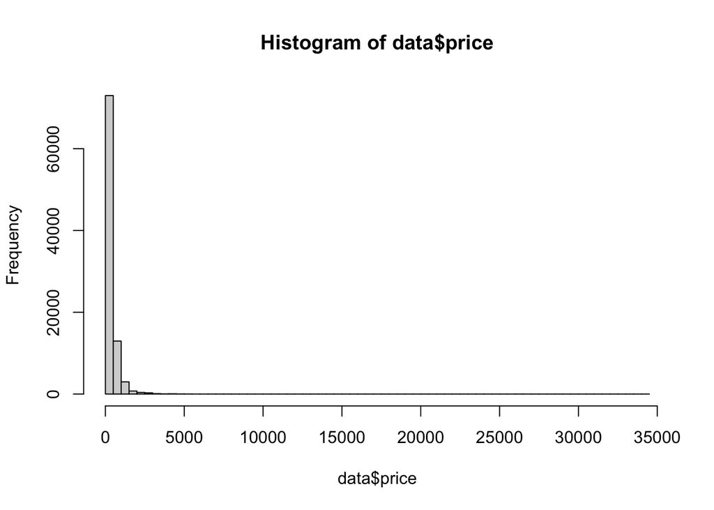

```r
# Plot histogram for price
hist(data$price, breaks=100)
```

The `price` distribution is significantly skewed. Using the imputation might not be useful. While it might be interesting to make a price prediction model based on the available features, I will leave for another work and focus on the objective of the long-term values of customer by segment.

I will remove the incomplete records. They account for 5% of the entire dataset, which is relatively trivial as we have enough data (over 90k rows) to make inference even after removing them.

```r
# Drop rows with missing price / user_id
data = data %>% drop_na()
dim(data)
```

```
## [1] 90558     3
```

I will explore customer transition based on year. To facilitate the data manipulation and analysis, convert `order_date` column to date format (%Y-%m-%d).

```r
# Change data type from character to date
data$order_date = as.Date(data$order_date)

# Extract year
data$year = as.numeric(format(data$order_date, '%Y'))
```

–

## Feature engineering

We will extract features needed for the analysis.

In order to make segmentation, I will make an evaluation on the purchase behaviors, using metrics like recency, frequency, average purchase and maximum purchase. For more granular segmentation analysis, customer’s first purchase will also be relevant to see if the customer is relatively new or existing.

**Recency** measures when is the date of latest purchase (first purchase is the date of first ever spending which is self-explanatory). In order to calculate these two metrics, we need to set a reference date of this analysis. Given the data ranges from December 2018 to December 2021 (3 years), I will assume that this analysis is performed in early 2022.

Other features are easier to compute. Unlike commodity sales such as groceries, the basket size of jewelry is not large, and I will assume that an individual **price** of a transaction represents the entire purchase.

```r
# Explore price distribution
# A single transaction accounts for fairly high amount of purchase
summary(data$price)
```

```
##     Min.  1st Qu.   Median     Mean  3rd Qu.     Max.
##     0.99   145.62   258.77   362.21   431.37 34448.60
```

```r
# Date range for order date in the dataset
summary(data$order_date)
```

```
##         Min.      1st Qu.       Median         Mean      3rd Qu.         Max.
## "2018-12-01" "2020-08-08" "2021-02-22" "2020-12-30" "2021-08-09" "2021-12-01"
```

```r
# Compute days from the reference date of analysis
ref_date = '2022-01-01'
data$days_since = as.numeric(difftime(time1=ref_date, time2=data$order_date, units='days'))
summary(data$days_since)
```

```
##    Min. 1st Qu.  Median    Mean 3rd Qu.    Max.
##   30.83  144.83  312.33  366.34  510.83 1126.83
```

There are many ways to aggregate the data records by user id. In order to extract all metrics as one go, I will use a sql query and the reference code will follow.

```r
# Create a SQL query to extract features
# by user_id

query = '
  SELECT user_id,
    MIN(days_since) recency,
    MAX(days_since) first_purchase,
    COUNT(*) frequency,
    AVG(price) avg_purchase,
    MAX(price) max_purchase
  FROM data
  GROUP BY user_id
  ORDER BY user_id
'

customers_2022 = sqldf(query)
tibble(customers_2022)
```

```
## # A tibble: 31,079 x 6
##    user_id recency first_purchase frequency avg_purchase max_purchase
##      <dbl>   <dbl>          <dbl>     <int>        <dbl>        <dbl>
##  1 1.31e18   553.            553.         1        272.         272.
##  2 1.31e18    87.8           883.         6        636.        1219.
##  3 1.31e18   135.            956.         5        563.        1520.
##  4 1.31e18   166.            166.         1        130          130
##  5 1.31e18   467.           1034.         8        258.         313.
##  6 1.31e18   735.            736.         2         12.0         12.0
##  7 1.31e18   131.           1074.        16        342.         870.
##  8 1.31e18   334.            334.         1        480.         480.
##  9 1.31e18   812.           1068.         7        192.         397.
## 10 1.31e18    50.8           801.         4        567.        2171.
## # … with 31,069 more rows
```

## EDA: Explortoary analysis